# Final Project Rough Draft

Authors

Darien Rodrigo

Rachel Le

Patrick Zhou

# **Spotify Wrapped 2026.5**

Have you ever wondered how your Spotify Wrapped comes together? Every year, Spotify users get a snapshot of their listening habits, including how many minutes they’ve spent on Spotify listening to songs, their most streamed song, and their top artist. Data scientists at Spotify are asked to develop algorithms to parse through copious amounts of user data and then present them in digestible and often visually intriguing ways. Now that is what we will do! What better time than the present to make our own Spotify Wrapped now that 2026 is halfway through! In the next several questions, you will be asked to clean, compile, and then visualize some of the top artists from this dataset.

```r
library(tidyverse)
library(knitr)
library(purrr)
```

## Part 1: Loading and Looking at Our Data

```r
spotify <- read_csv('https://raw.githubusercontent.com/FisherFraley/Datafest_Workshop/refs/heads/main/spotify_dataset.csv')
```

```
──────────────────────────────────────────────────────── Delimiter: "," chr
(5): track_id, artists, album_name, track_name, track_genre dbl (15): ...1,
popularity, duration_ms, danceability, energy, key, loudness... lgl (1):
explicit
```

Our dataset is quite intimidating! Breaking it down and understanding what constitutes it makes it easier to understand what we *do* and do *not* need.

### Spotify Data Definitions

Below are the meanings of what each column represents—take note of which are numeric, character, or logical variables.

[output not shown]

### Inspecting Our Data

1. What are the names of our columns?

```r
names(spotify)
```

```
 [1] "...1"             "track_id"         "artists"          "album_name"
 [5] "track_name"       "popularity"       "duration_ms"      "explicit"
 [9] "danceability"     "energy"           "key"              "loudness"
[13] "mode"             "speechiness"      "acousticness"     "instrumentalness"
[17] "liveness"         "valence"          "tempo"            "time_signature"
[21] "track_genre"
```

2. What are some of the datatypes we’re working with?

```r
glimpse(spotify)
```

```
Rows: 114,000
Columns: 21
$ ...1             <dbl> 0, 1, 2, 3, 4, 5, 6, 7, 8, 9, 10, 11, 12, 13, 14, 15,…
$ track_id         <chr> "5SuOikwiRyPMVoIQDJUgSV", "4qPNDBW1i3p13qLCt0Ki3A", "…
$ artists          <chr> "Gen Hoshino", "Ben Woodward", "Ingrid Michaelson;ZAY…
$ album_name       <chr> "Comedy", "Ghost (Acoustic)", "To Begin Again", "Craz…
$ track_name       <chr> "Comedy", "Ghost - Acoustic", "To Begin Again", "Can'…
$ popularity       <dbl> 73, 55, 57, 71, 82, 58, 74, 80, 74, 56, 74, 69, 52, 6…
$ duration_ms      <dbl> 230666, 149610, 210826, 201933, 198853, 214240, 22940…
$ explicit         <lgl> FALSE, FALSE, FALSE, FALSE, FALSE, FALSE, FALSE, FALS…
$ danceability     <dbl> 0.676, 0.420, 0.438, 0.266, 0.618, 0.688, 0.407, 0.70…
$ energy           <dbl> 0.4610, 0.1660, 0.3590, 0.0596, 0.4430, 0.4810, 0.147…
$ key              <dbl> 1, 1, 0, 0, 2, 6, 2, 11, 0, 1, 8, 4, 7, 3, 2, 4, 2, 1…
$ loudness         <dbl> -6.746, -17.235, -9.734, -18.515, -9.681, -8.807, -8.…
$ mode             <dbl> 0, 1, 1, 1, 1, 1, 1, 1, 1, 1, 1, 1, 0, 1, 1, 1, 1, 0,…
$ speechiness      <dbl> 0.1430, 0.0763, 0.0557, 0.0363, 0.0526, 0.1050, 0.035…
$ acousticness     <dbl> 0.0322, 0.9240, 0.2100, 0.9050, 0.4690, 0.2890, 0.857…
$ instrumentalness <dbl> 1.01e-06, 5.56e-06, 0.00e+00, 7.07e-05, 0.00e+00, 0.0…
$ liveness         <dbl> 0.3580, 0.1010, 0.1170, 0.1320, 0.0829, 0.1890, 0.091…
$ valence          <dbl> 0.7150, 0.2670, 0.1200, 0.1430, 0.1670, 0.6660, 0.076…
$ tempo            <dbl> 87.917, 77.489, 76.332, 181.740, 119.949, 98.017, 141…
$ time_signature   <dbl> 4, 4, 4, 3, 4, 4, 3, 4, 4, 4, 4, 3, 4, 4, 4, 3, 4, 4,…
$ track_genre      <chr> "acoustic", "acoustic", "acoustic", "acoustic", "acou…
```

## Part 2: Clean the Data!

Looking at our data, with all these artists and how much data we have on them, it would be a lot of trouble to make sure we have every piece of data that we need on each of these artists!

Luckily for us, we can use some handy functions to clean our data. Create a new dataframe named `spotify_cleaned` and perform the following tasks:

3. First, check for missing values.

```r
colSums(is.na(spotify))
```

```
            ...1         track_id          artists       album_name
               0                0                1                1
      track_name       popularity      duration_ms         explicit
               1                0                0                0
    danceability           energy              key         loudness
               0                0                0                0
            mode      speechiness     acousticness instrumentalness
               0                0                0                0
        liveness          valence            tempo   time_signature
               0                0                0                0
     track_genre
               0
```

4. What columns have missing data?

```r
# Track Name, Artists, Album Name have missing data
```

5. There are 21 total columns in our dataset. Remove all columns *except* the following: `track_id`, `artists`, `album_name`,`track_name`, `popularity`, `duration_ms`, and `track_genre`.

```r
spotify_clean <- spotify |>
  select(track_id, artists, album_name, track_name, popularity, duration_ms, track_genre)
```

6. Which rows have important information missing? In other words, if rows are missing `track_name`, `artists`, or `album_name` should they even be included in our data set? Remove rows where any of the aforementioned columns contain `NA`.

```r
spotify_clean <- na.omit(spotify_clean)
```

7. Are there any duplicate rows? Remove them!

```r
spotify_clean <- unique(spotify_clean)
```

8. Note that column `duration_ms` is in milliseconds. It’s quite tough to imagine a song in terms of milliseconds. Convert these milliseconds to minutes.

```r
spotify_clean <- spotify_clean |>
  mutate(
    duration_min = duration_ms / 60000
  )
```

## Part 3: Use the Clean Dataset for Analysis

9. Now that your dataset has been cleaned, you can begin exploring the songs that make up Spotify’s catalog. Before identifying trends, it is useful to understand what a “typical” song looks like.

   Calculate summary statistics for the following variables across all songs:
   - Popularity
   - Duration (in minutes)
   - Danceability
   - Energy

   Based on these summaries, describe the average song in this dataset. What characteristics seem most common?

```r
spotify <- spotify |>
  mutate(
    duration_min = duration_ms / 60000
  )
summary(
  spotify[, c("popularity","duration_min","danceability","energy")]
)
```

```
   popularity      duration_min     danceability        energy
 Min.   :  0.00   Min.   : 0.000   Min.   :0.0000   Min.   :0.0000
 1st Qu.: 17.00   1st Qu.: 2.901   1st Qu.:0.4560   1st Qu.:0.4720
 Median : 35.00   Median : 3.548   Median :0.5800   Median :0.6850
 Mean   : 33.24   Mean   : 3.800   Mean   :0.5668   Mean   :0.6414
 3rd Qu.: 50.00   3rd Qu.: 4.358   3rd Qu.:0.6950   3rd Qu.:0.8540
 Max.   :100.00   Max.   :87.288   Max.   :0.9850   Max.   :1.0000
```

10. Spotify assigns every song a popularity score ranging from 0 to 100. Data scientists often begin by examining how a variable is distributed before drawing conclusions from it.

    Create an appropriate visualization of song popularity.

    After creating your visualization, answer the following:
    - Is song popularity normally distributed?
    - Are most songs highly popular or relatively unknown?
    - Are there any unusual patterns or outliers that stand out?

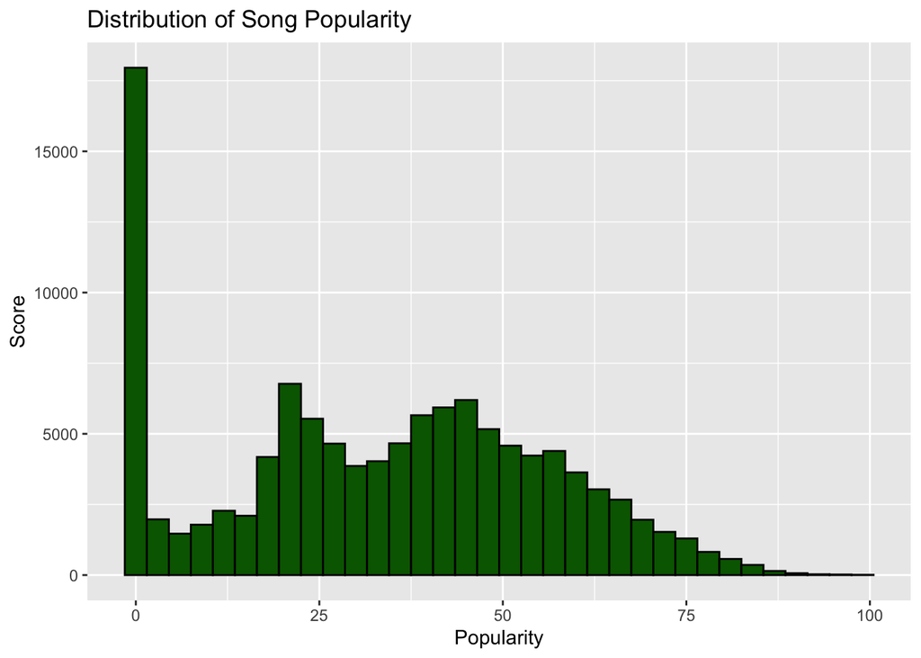

```r
ggplot(spotify_clean,
       aes(x = popularity)) +
  geom_histogram(binwidth = 3,
                 fill = "darkgreen",
                 color = "black") +
  labs(
    title = "Distribution of Song Popularity",
    x = "Popularity",
    y = "Score"
  )
```

11. Imagine that this dataset represents your listening history for the first half of 2026. Spotify Wrapped often highlights a listener’s favorite artists and genres.

    Identify:
    - Your top artist (the artist appearing most often)
    - Your top five artists
    - Your top genre

    Create a table summarizing your findings.

    What do these results suggest about your listening habits?

```r
top_artist <- spotify_clean |>
  arrange(desc(popularity)) |>
  select(artists)
head(top_artist, 1)
```

```
# A tibble: 1 × 1
  artists
  <chr>
1 Sam Smith;Kim Petras
```

```r
head(top_artist)
```

```
# A tibble: 6 × 1
  artists
  <chr>
1 Sam Smith;Kim Petras
2 Sam Smith;Kim Petras
3 Bizarrap;Quevedo
4 David Guetta;Bebe Rexha
5 David Guetta;Bebe Rexha
6 Manuel Turizo
```

```r
top_genre <- spotify_clean |>
  arrange(desc(popularity)) |>
  select(track_genre)

head(top_genre, 1)
```

```
# A tibble: 1 × 1
  track_genre
  <chr>
1 dance
```

12. Suppose Spotify generates a random playlist containing 25 songs from its catalog.

    Would that playlist tend to contain highly popular songs, or would it mostly contain average songs?

    To investigate:
    1. Randomly sample 25 songs.
    2. Compute the playlist’s average popularity.
    3. Repeat this process 1,000 times.

    Visualize the resulting distribution of average popularity scores.

    Based on your simulation, what popularity score would you expect for a typical playlist?

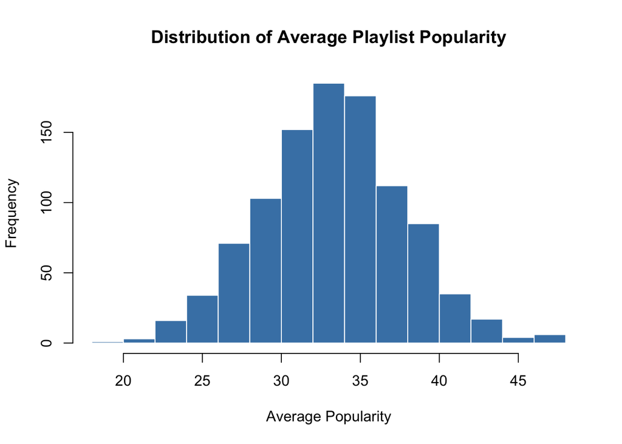

```r
set.seed(100)

rand_playlist <- spotify_clean |>
  map_dbl(
  .x = 1:1000,
  .f = ~ mean(sample(spotify_clean$popularity, size = 25))
)


hist(
  rand_playlist,
  main = "Distribution of Average Playlist Popularity",
  xlab = "Average Popularity",
  col = "steelblue",
  border = "white"
)
```

```r
mean(rand_playlist)
```

```
[1] 33.27828
```

```r
sd(rand_playlist)
```

```
[1] 4.474971
```